# Birth Weight Prediction

## 9. Testing

```
2219/2219 ━━━━━━━━━━━━━━━━━━━━ 31s 13ms/step - loss: 86.3283 - mae: 6.4021 - val_loss: 4.8405 - val_mae: 1.3933
2219/2219 ━━━━━━━━━━━━━━━━━━━━ 29s 13ms/step - loss: 7.2845 - mae: 1.8780 - val_loss: 2.6425 - val_mae: 1.0280
2219/2219 ━━━━━━━━━━━━━━━━━━━━ 29s 13ms/step - loss: 3.8312 - mae: 1.3978 - val_loss: 1.4628 - val_mae: 0.8378
2219/2219 ━━━━━━━━━━━━━━━━━━━━ 29s 13ms/step - loss: 2.1100 - mae: 1.0736 - val_loss: 1.4699 - val_mae: 0.8833
2219/2219 ━━━━━━━━━━━━━━━━━━━━ 29s 13ms/step - loss: 1.8323 - mae: 0.9963 - val_loss: 1.3390 - val_mae: 0.8335
2219/2219 ━━━━━━━━━━━━━━━━━━━━ 30s 13ms/step - loss: 1.6155 - mae: 0.9273 - val_loss: 1.3438 - val_mae: 0.8247
2219/2219 ━━━━━━━━━━━━━━━━━━━━ 29s 13ms/step - loss: 1.5645 - mae: 0.8959 - val_loss: 1.3407 - val_mae: 0.8186
2219/2219 ━━━━━━━━━━━━━━━━━━━━ 30s 13ms/step - loss: 1.5118 - mae: 0.8780 - val_loss: 1.3448 - val_mae: 0.8194
2219/2219 ━━━━━━━━━━━━━━━━━━━━ 30s 13ms/step - loss: 1.4806 - mae: 0.8629 - val_loss: 1.4624 - val_mae: 0.8478
2219/2219 ━━━━━━━━━━━━━━━━━━━━ 30s 13ms/step - loss: 1.4955 - mae: 0.8630 - val_loss: 1.3303 - val_mae: 0.8196
2219/2219 ━━━━━━━━━━━━━━━━━━━━ 30s 13ms/step - loss: 1.4700 - mae: 0.8567 - val_loss: 1.4232 - val_mae: 0.8500
2219/2219 ━━━━━━━━━━━━━━━━━━━━ 30s 14ms/step - loss: 1.4621 - mae: 0.8547 - val_loss: 1.3387 - val_mae: 0.8106
2219/2219 ━━━━━━━━━━━━━━━━━━━━ 31s 14ms/step - loss: 1.4811 - mae: 0.8571 - val_loss: 1.3657 - val_mae: 0.8161
2219/2219 ━━━━━━━━━━━━━━━━━━━━ 30s 14ms/step - loss: 1.4841 - mae: 0.8559 - val_loss: 1.3850 - val_mae: 0.8254
2219/2219 ━━━━━━━━━━━━━━━━━━━━ 30s 14ms/step - loss: 1.4775 - mae: 0.8580 - val_loss: 1.3912 - val_mae: 0.8277
2219/2219 ━━━━━━━━━━━━━━━━━━━━ 30s 14ms/step - loss: 1.4575 - mae: 0.8522 - val_loss: 1.3854 - val_mae: 0.8277
2219/2219 ━━━━━━━━━━━━━━━━━━━━ 30s 14ms/step - loss: 1.4582 - mae: 0.8498 - val_loss: 1.3324 - val_mae: 0.8121
2219/2219 ━━━━━━━━━━━━━━━━━━━━ 31s 14ms/step - loss: 1.4500 - mae: 0.8494 - val_loss: 1.3670 - val_mae: 0.8246
2219/2219 ━━━━━━━━━━━━━━━━━━━━ 30s 14ms/step - loss: 1.4997 - mae: 0.8654 - val_loss: 1.3494 - val_mae: 0.8229
2219/2219 ━━━━━━━━━━━━━━━━━━━━ 30s 14ms/step - loss: 1.4581 - mae: 0.8556 - val_loss: 1.3451 - val_mae: 0.8205
317/317 ━━━━━━━━━━━━━━━━━━━━ 0s 1ms/step
Dropout + L2 Regularized Model Performance on Test Set:
MAE: 0.8213
MSE: 1.1060
R² Score: 0.3540
```

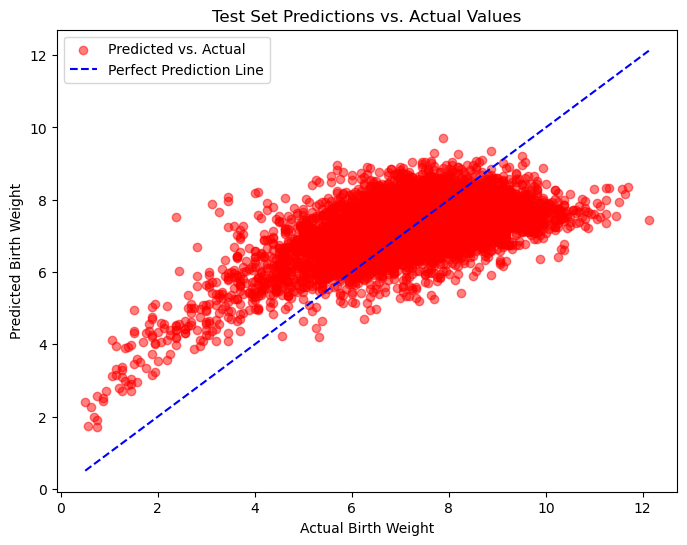

```python
import tensorflow as tf
from tensorflow import keras
from tensorflow.keras import layers
from tensorflow.keras.regularizers import l2
from tensorflow.keras.callbacks import EarlyStopping
import matplotlib.pyplot as plt
from sklearn.metrics import mean_absolute_error, mean_squared_error, r2_score

# Step 1: Build the Dropout + L2 Regularized Model
def build_dropout_l2_model():
    model = keras.Sequential([
        keras.Input(shape=(X_train_tensor.shape[1],)),  # Explicit input layer
        layers.Dense(128, activation="relu", kernel_regularizer=l2(0.01)),
        layers.Dropout(0.3),  # Dropout after first hidden layer
        layers.Dense(64, activation="relu", kernel_regularizer=l2(0.01)),
        layers.Dropout(0.3),  # Dropout after second hidden layer
        layers.Dense(32, activation="relu", kernel_regularizer=l2(0.01)),
        layers.Dropout(0.3),  # Dropout after third hidden layer
        layers.Dense(16, activation="relu", kernel_regularizer=l2(0.01)),
        layers.Dropout(0.3),  # Dropout after fourth hidden layer
        layers.Dense(1)  # Output layer (regression)
    ])
    model.compile(optimizer=keras.optimizers.Adam(learning_rate=0.001),
                  loss="mse",
                  metrics=["mae"])
    return model

# Initialize the model
dropout_l2_model = build_dropout_l2_model()

# Step 2: Train the Model with Early Stopping
early_stopping = EarlyStopping(monitor="val_loss", patience=10, restore_best_weights=True)

history_dropout_l2 = dropout_l2_model.fit(
    X_train_tensor, y_train_tensor,
    validation_data=(X_val_tensor, y_val_tensor),
    epochs=150,  # More epochs to allow training stabilization
    batch_size=32,
    callbacks=[early_stopping],
    verbose=1
)

# Step 3: Evaluate the Model on the **Test Set**
test_preds_dropout_l2 = dropout_l2_model.predict(X_test_tensor).flatten()
test_mae_dropout_l2 = mean_absolute_error(y_test_tensor.numpy(), test_preds_dropout_l2)
test_mse_dropout_l2 = mean_squared_error(y_test_tensor.numpy(), test_preds_dropout_l2)
test_r2_dropout_l2  = r2_score(y_test_tensor.numpy(), test_preds_dropout_l2)

print("Dropout + L2 Regularized Model Performance on Test Set:")
print(f"MAE: {test_mae_dropout_l2:.4f}")
print(f"MSE: {test_mse_dropout_l2:.4f}")
print(f"R² Score: {test_r2_dropout_l2:.4f}")

# Step 4: Visualize Test Set Predictions vs. Actual
plt.figure(figsize=(8, 6))
plt.scatter(y_test_tensor.numpy(), test_preds_dropout_l2, color='red', alpha=0.5, label="Predicted vs. Actual")
plt.plot([min(y_test_tensor.numpy()), max(y_test_tensor.numpy())],
         [min(y_test_tensor.numpy()), max(y_test_tensor.numpy())],
         color='blue', linestyle="--", label="Perfect Prediction Line")
plt.xlabel("Actual Birth Weight")
plt.ylabel("Predicted Birth Weight")
plt.title("Test Set Predictions vs. Actual Values")
plt.legend()
plt.show()
```

## 10. Analysis and Conclusion

The results demonstrate the progression from a simple baseline model to increasingly sophisticated neural network architectures, highlighting the effects of overfitting, regularization, and tuning techniques.

**Baseline vs. Neural Network Performance**

The baseline model, which simply predicts the mean birth weight, performed poorly with an MAE of 0.9697 and an R² score of -0.0007, meaning it captured almost no variance in the data. However, introducing a shallow neural network with Adam optimization and early stopping significantly improved performance, reducing MAE to 0.8528 and increasing R² to 0.3121. This confirms that neural networks are capable of learning meaningful patterns in the data.

**The Effect of Dropout Regularization**

To combat overfitting, dropout layers were introduced, which improved generalization. The MAE decreased from 0.8528 to 0.8137, and the R² score improved to 0.3761. This confirmed that dropout effectively prevents excessive reliance on specific neurons, promoting a more distributed representation of features.

**Testing Deeper Networks and Batch Size Adjustments**

Increasing the depth of the network by adding more layers resulted in slightly worse performance, with R² decreasing to 0.3579, suggesting that simply making the model deeper does not necessarily improve performance. On the other hand, increasing the batch size to 256 performed almost identically to the best dropout model, indicating that batch size adjustments alone do not always yield major improvements.

### Future Work

Moving forward, we can explore Bayesian Optimization to fine-tune hyperparameters such as learning rate, dropout rate, and batch size. Additionally, experimenting with alternative activation functions (such as Swish or LeakyReLU) and trying L1 Regularization (or ElasticNet, which combines L1 and L2) could further improve the model’s predictive power.

## 11. References

Chollet, F. (2018). Deep Learning With Python. Manning Publications.

Kaggle. Birth weight prediction [Data set]. Retrieved from https://www.kaggle.com/competitions/birth-weight-prediction/data